# Trend Estimation

# 1 Overview

Five data sets have been created with losses randomly generated.

The data sets increase in complexity with extra features that mask the underlying trend.

The goal is to estimate the trend rate that the claims are subject to.

# 2 Starter For Ten

- All losses are fully developed
- Fixed number of losses (50) per year
- All losses from a single loss distribution

File: data_set_1.csv

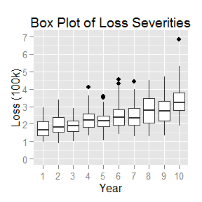

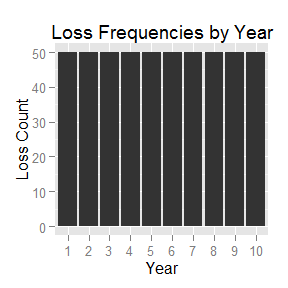

# 3 Random Trend Rates

- All losses fully developed
- Random number of losses per year
- Random trend rate for each year (all sampled from the same distribution)

File: data_set_2.csv

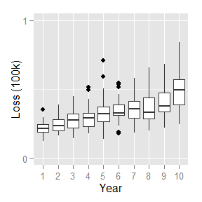

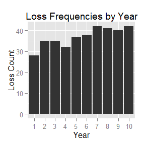

# 4 IBNR

- All losses fully developed
- Random number of losses per year
- Random trend rate for each year (all sampled from the same distribution)
- IBNR pattern applied to each year to limit reported claims

File: data_set_3.csv

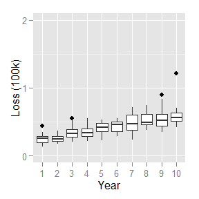

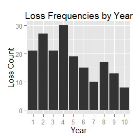

# 5 IBNER

- Random number of losses per year
- Random trend rate for each year (all sampled from the same distribution)
- IBNR pattern applied to each year to limit reported claims
- IBNER pattern (random) applied to each loss

File: data_set_4.csv

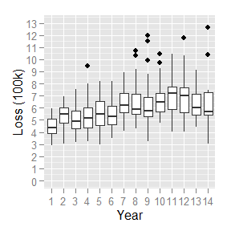

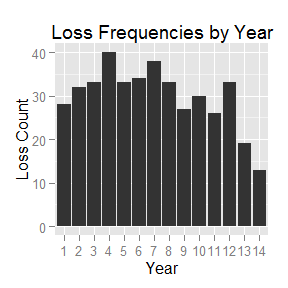

# 6 Notification Level

- Random number of losses per year
- Random trend rate for each year (all sampled from the same distribution)
- IBNR pattern applied to each year to limit reported claims
- IBNER pattern (random) applied to each loss
- Notification level of 750,000

File: data_set_5.csv

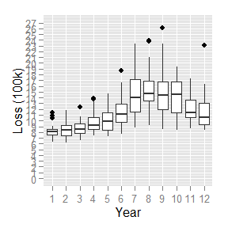

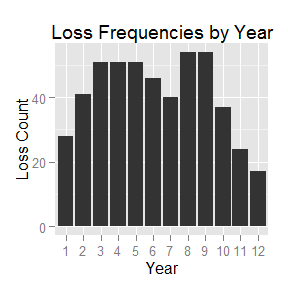